# AVL Trees

*Named after the inventors **A**delson-**V**elsky and **L**andis*

## BST Performance Review

- The $O(\log n)$ performance of a BST depends on the balance of the tree
- When the difference in the number of children on either side of a node gets large, the performance degrades.

## Examples of imbalance

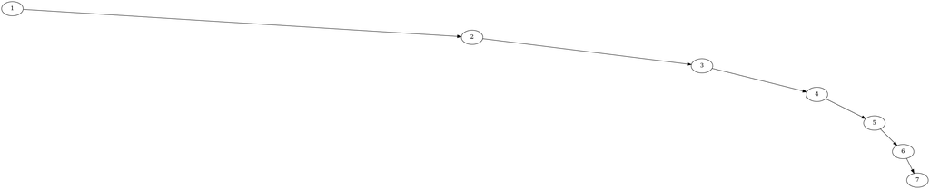

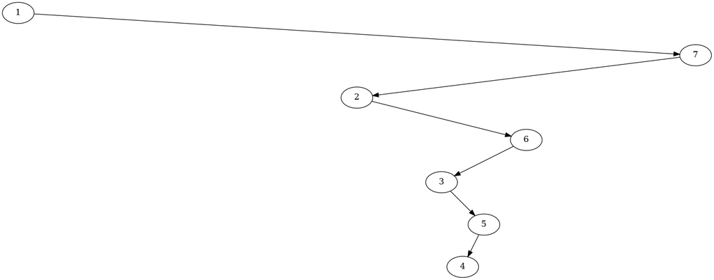

## Defining Balance

We'll define "balance" to mean that the difference in height between the children of a node is always less than 2.

We can score the balance of a node with $height(right) - height(left)$

The height of a `nullptr` is $-1$

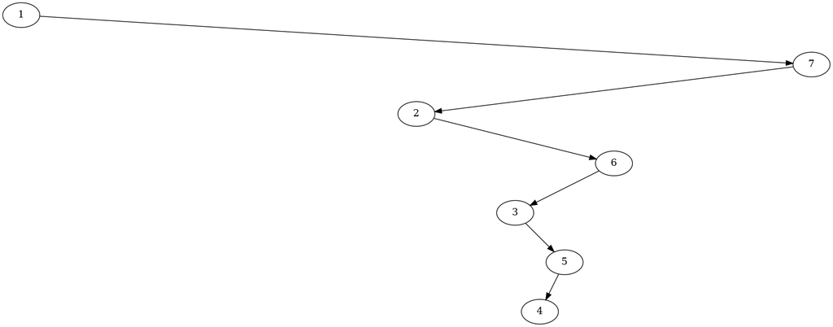

What is the balance of node 3?

$height(5) - height(nullptr) = 1 - (-1) = 2$

What is the balance of node 7?

$height(nullptr) - height(2) = (-1) - 4 = -5$

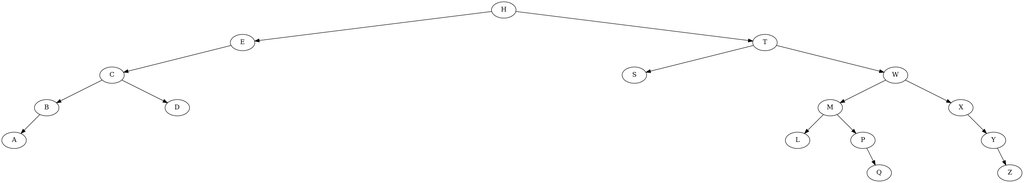

Work with a partner:

What is the balance of **C**, **E**, **W**, and **T**?

- What is the balance of C?
  - $height(D) - height(B) = 0 - 1 = -1$
- What is the balance of E?
  - $height(nullptr) - height(C) = (-1) - 2 = -3$
- What is the balance of W?
  - $height(X) - height(M) = 2 - 2 = 0$
- What is the blance of T?
  - $height(W) - height(S) = 3 - 0 = 3$

## Rebalance

### Left-Left and Right-Right

Remember, the balance of a node is $height(right) - height(left)$.

When you have a node with negative balance <= -2 (i.e. a heavy left branch) whose left node also has negative balance, we have a **left-left** imbalance.

When you have a node with positive balance >= 2 (i.e. a heavy right branch) whose right node also has positive balance, we have a **right-right** imbalance.

These two cases are symmetrically and are handled with the same strategy.

## A simple example

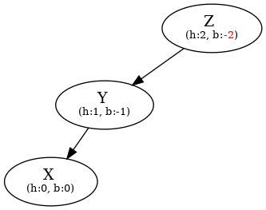

#### Reblance Intuition

- The left side of Z is taller than the right side of Z (which is empty).
  - This means the left side reaches deeper than the right.
- If we promote the left side (move it closer to the root), and make the right side a child of the left (move it further from the root), then the left side won't reach as deep (good!) and the right side will reach deeper (good!)

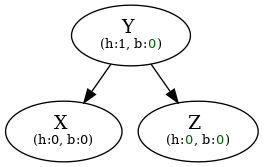

Work with a partner.

Annotate each node with its height and balance.

Which node is imbalanced? What kind of imbalance is it?

What will this tree look like after performing a rebalance?

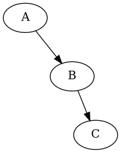

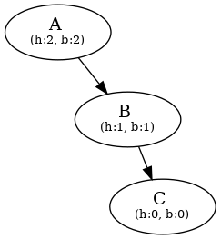

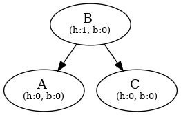

## A more complex example

Let's add B, A, and D to an empty AVL tree:

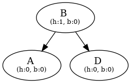

Now let's insert C and E:

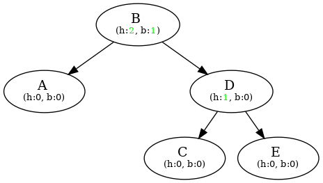

And now for the punchline!

Let's insert F into our tree:

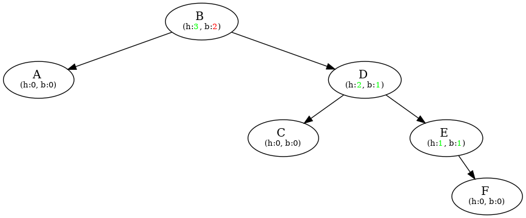

Time for a rebalance!

- B has balance >= 2, meaning it is heavy on the right, so we check the right child
- D has balance > 0, meaning it is also heavy on the right
- So we have **right-right**

In this scenario, C becomes the new right child of B.

So:

- The new (local) root will be D
- B's right child will be C
- D's left child will be B

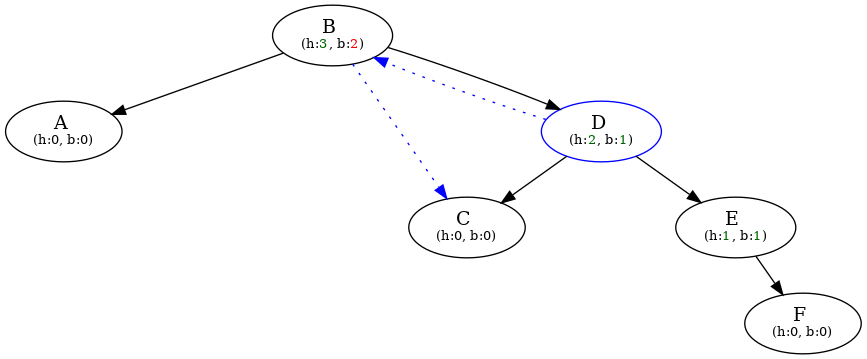

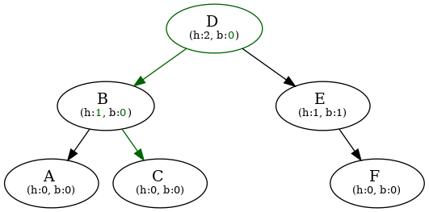

Work with a partner.

Annotate each node with its height and balance.

Which node is imbalanced? What kind of imbalance is it?

What will this tree look like after performing a rebalance?

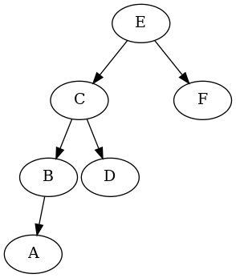

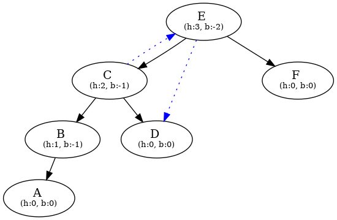

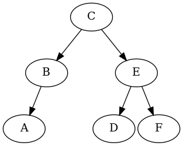

### Key Ideas: left-left and right-right

- When the imbalanced node and the child on the heavier side have the same imbalance sign (i.e. both positive or both negative), a simple left-left or right-right rotation will rebalance the tree
- To rebalance left-left:

  ```
  void promote_left_child(Node*& node) {
      auto new_root = node->left;
      node->left = node->left->right;
      new_root->right = node;
      node = new_root;
  }
  ```

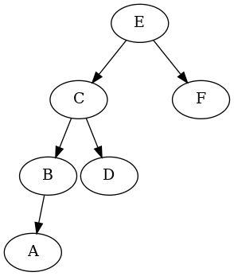

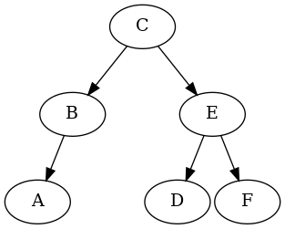

### Rebalance: Left-right and Right-left

- When the sign of the balance of the heavier child does **not** match the sign of the balance of the parent, we have a **left-right** or **right-left** imbalance.

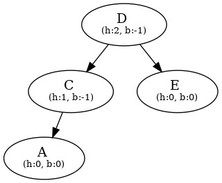

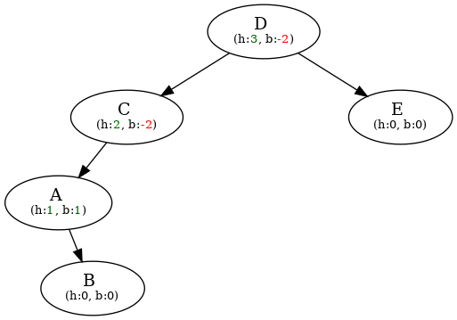

You solve a **left-right** or **right-left** imbalance in two steps:

1. Rotate the heavy child to create a **left-left** or **right-right** imbalance
2. Rotate the original node

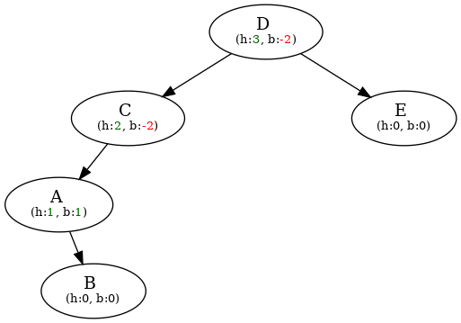

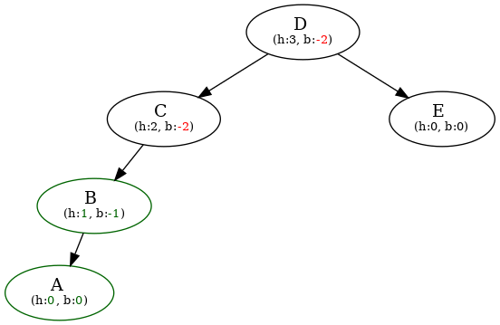

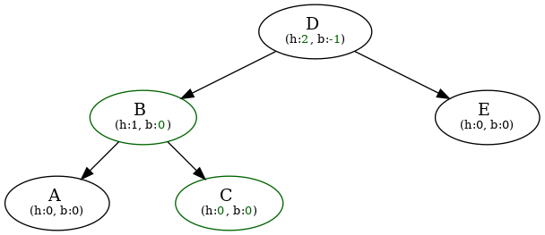

Work with a partner.

What is the outcome of adding D?

- First, add D and update the height and balance of each node
- Then show the rotation steps needed to balance the tree

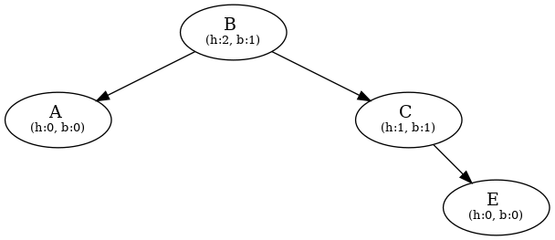

Add D and update the heights and balances

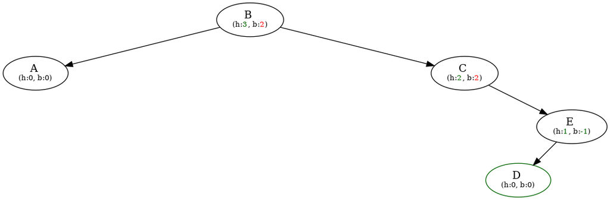

The right node has a balance < 0, so we need two rotations.

First we will rotate E to have the same balance as C.

Then we can rotate C to fix the imbalance.

Rotate E

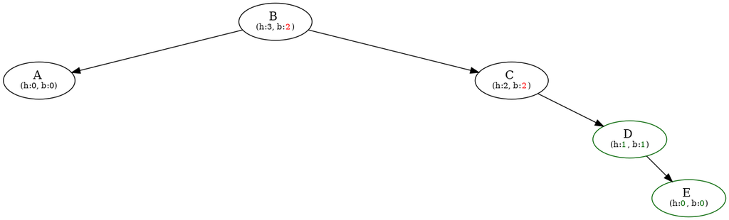

Rotate C

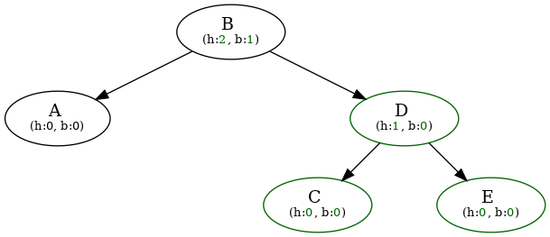

## Rotate Algorithm

- Detect imbalance
  - If a node has a balance > 1, we need to rotate on the right.
  - If a node has a balance < -1, we need to rotate on the left.
- If the child on the heavy side has balance of opposite sign, rotate it up.
  - Now the node will have a heavy child with balance in the same sign
- Now rotate the node to correct the imbalance

```
void promote_left_child(Node*& node) {
    auto new_root = node->left;
    node->left = node->left->right;
    new_root->right = node;
    node = new_root;
}
```

```
void promote_right_child(Node*& node) {
    auto new_root = node->right;
    node->right = node->right->left;
    new_root->left = node;
    node = new_root;
}
```

```
void reblance_negative(Node*& node) {
    // Is the sign of the left child positive?
    if (node->left.balance > 0) {
        // Promote left's right child
        promote_right_child(node->left);
    }

    // Now rotate left
    promote_left_child(node);
}
```

```
void reblance_positive(Node*& node) {
    // Is the sign of the left child negative?
    if (node->left.balance < 0) {
        // Promote right's left child
        promote_left_child(node->right);
    }

    // Now rotate right
    promote_right_child(node);
}
```

## Big-O complexity of rotate

What is the big-O complexity of rotating during insert?

- Performing the actual insert is unchanged: $O(\log n)$
- As the recursion unwinds, we do basic updates to height and balance: $O(1)$
- If we find a need to rebalance, I need to change a constant number of pointers and update height and balacne: $O(1)$
- So total complexity is still bounded by the insert: $O(\log n)$

## Key Ideas

- Imbalanced search trees have poor performance
- We can keep a tree balanced by immediately correcting an imbalance > 1 or < -1.
  - The rebalance work is $O(1)$
  - Rebalancing requires one or two rotation steps
    - If the sign of the balance of the imbalanced node and its heavy child do not agree, rotate the heavy child so the sign of the balance agrees
    - Rotate the imbalanced node

```python
// How to return 2 values?
// Not needed for the lab
// Note: for AVL, you can also just update the heights of each node as you go.
//  So, have each node store the height, and as you unwind the recursion, update the heights.

class Tree {

    int new_height_of_child;

    bool _add(Node*& node, T value, int& out_new_height) {
        int new_height_of_left;
        bool added = _add(node->left, value, new_height_of_left);
        out_new_height = node.height = max(node->right.height, new_height_of_left);
    }

    bool _add(Node*& node, T value) {
        bool added = _add(node->left, value);
        new_height_of_child = node.height = max(node->right.height, new_height_of_child);
    }

    Stuff _add(Node*& node, T value) {
        // ...
        return Stuff(true, height);
    }
}

struct Stuff {
    bool added;
    int new_height;
}
```